# AMA All Jobs Report

# All Employees

This report visualizes the Adaptive Moving Average (AMA) results for each industry (all jobs).

# Total nonfarm

AMA Job Results

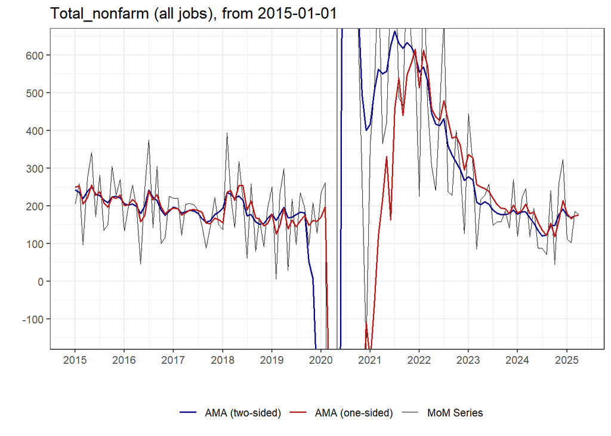

AMA Look-back Window (Right)

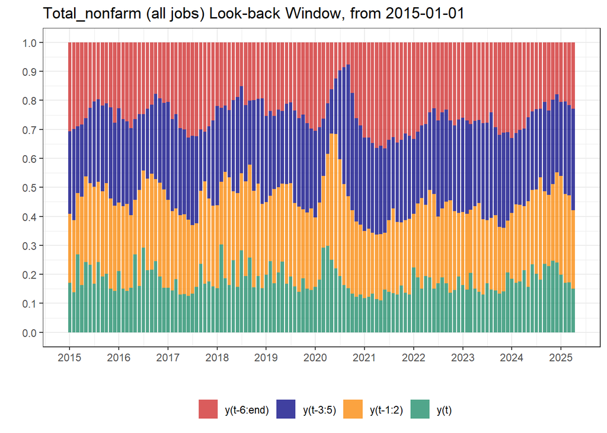

## Total private

AMA Job Results

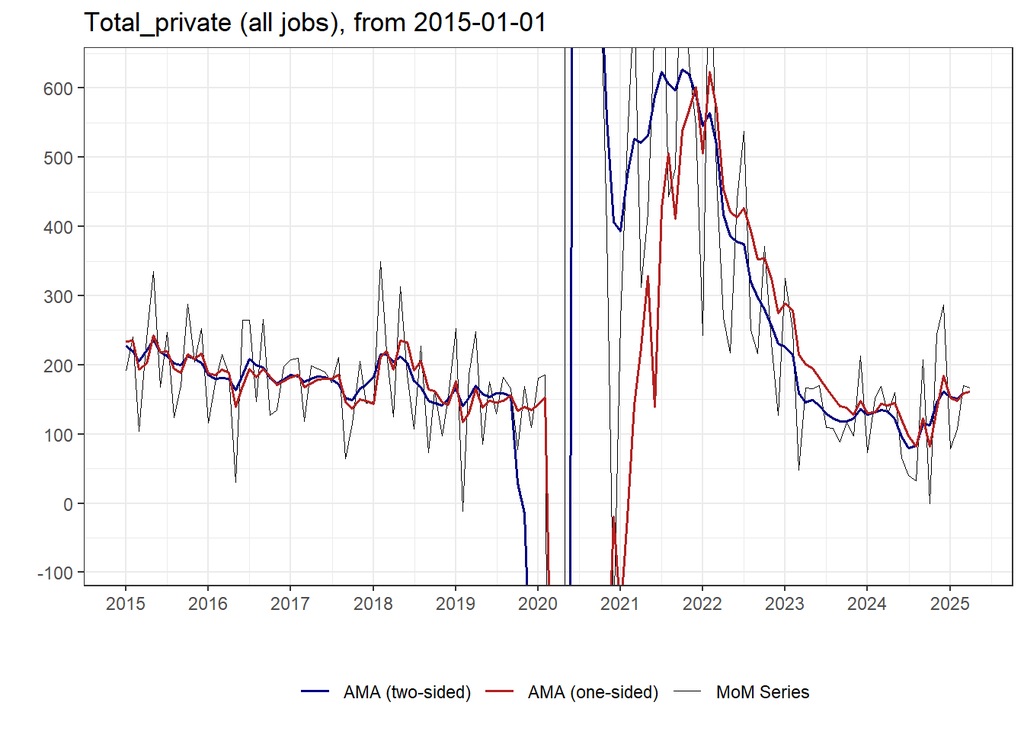

AMA Look-back Window (Right)

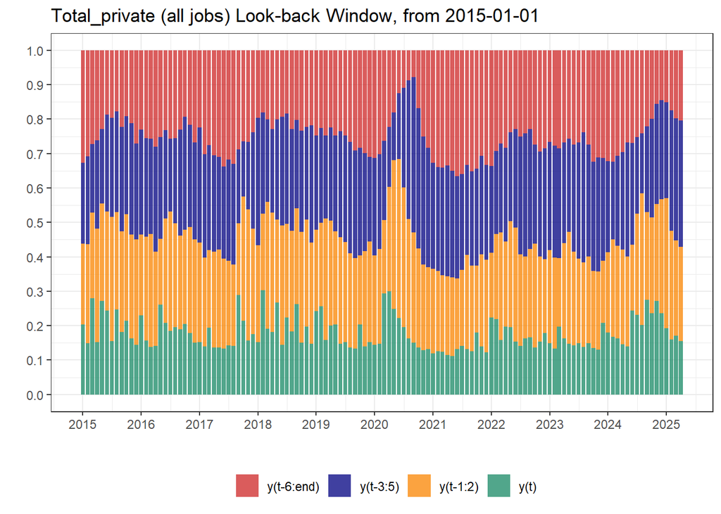

### Goods-producing

AMA Job Results

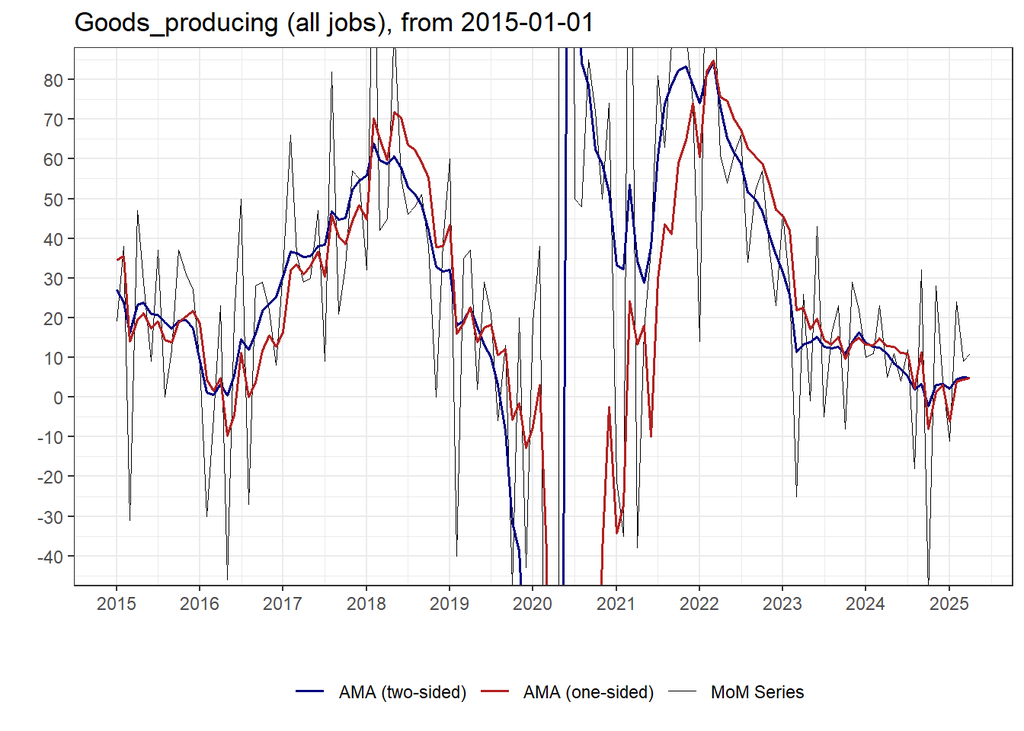

AMA Look-back Window (Right)

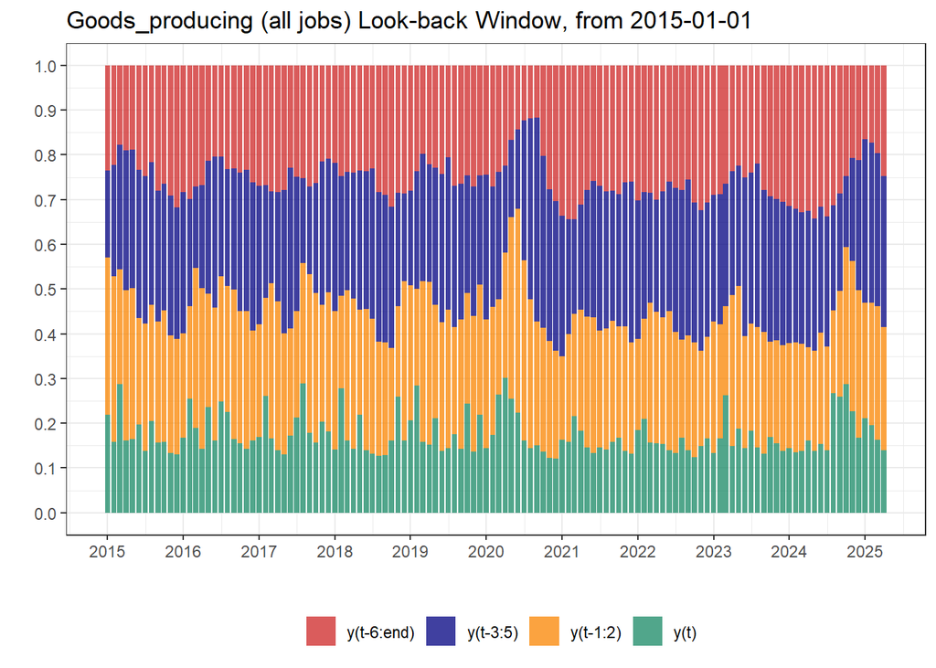

#### Mining and logging

AMA Job Results

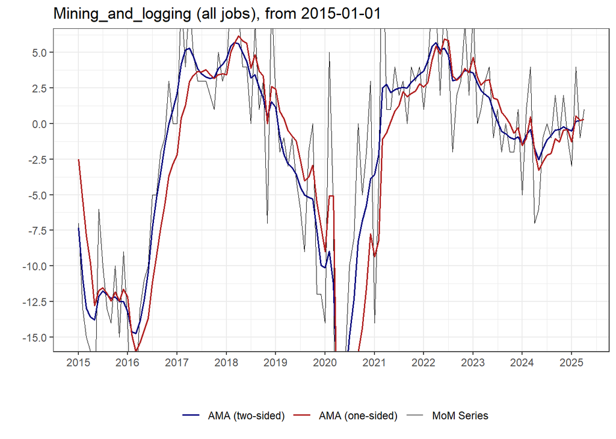

AMA Look-back Window (Right)

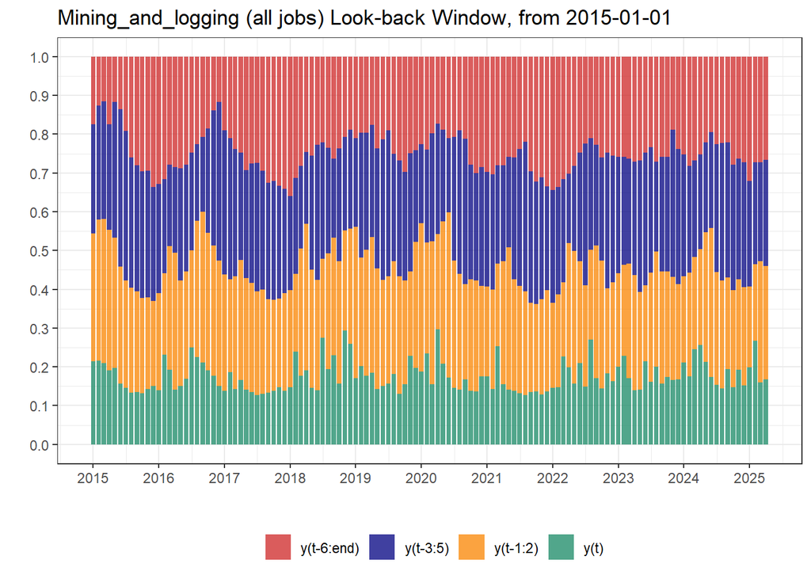

#### Construction

AMA Job Results

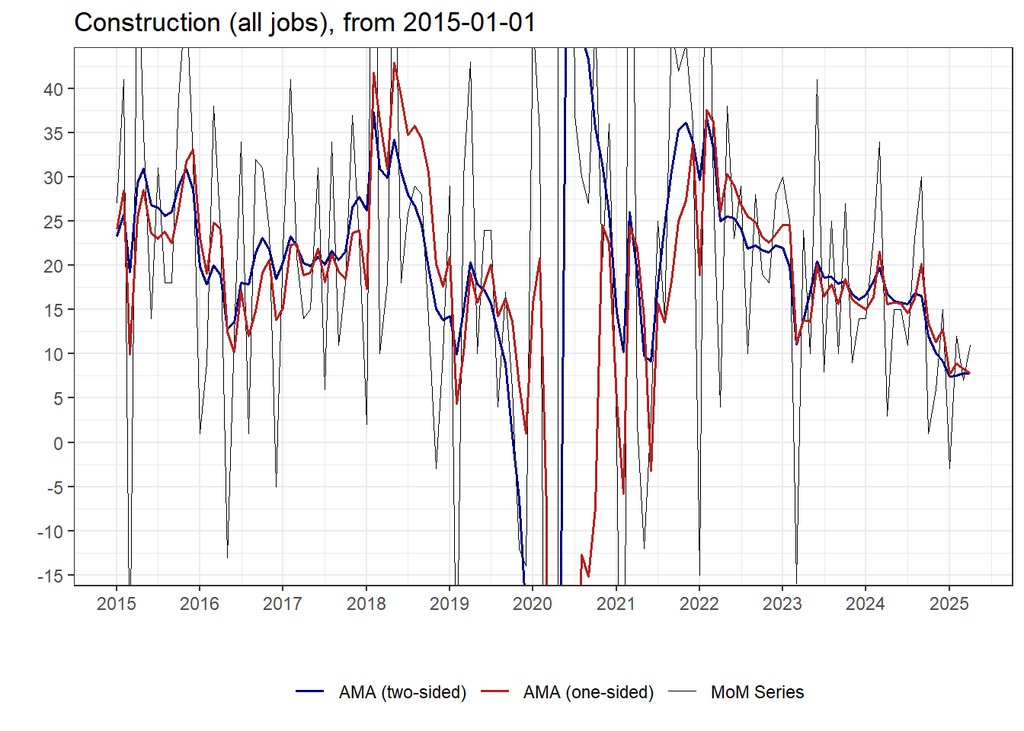

AMA Look-back Window (Right)

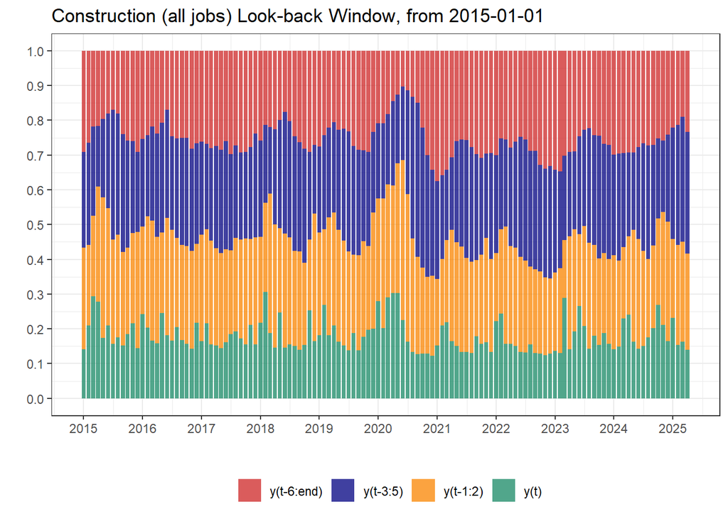

#### Manufacturing

AMA Job Results

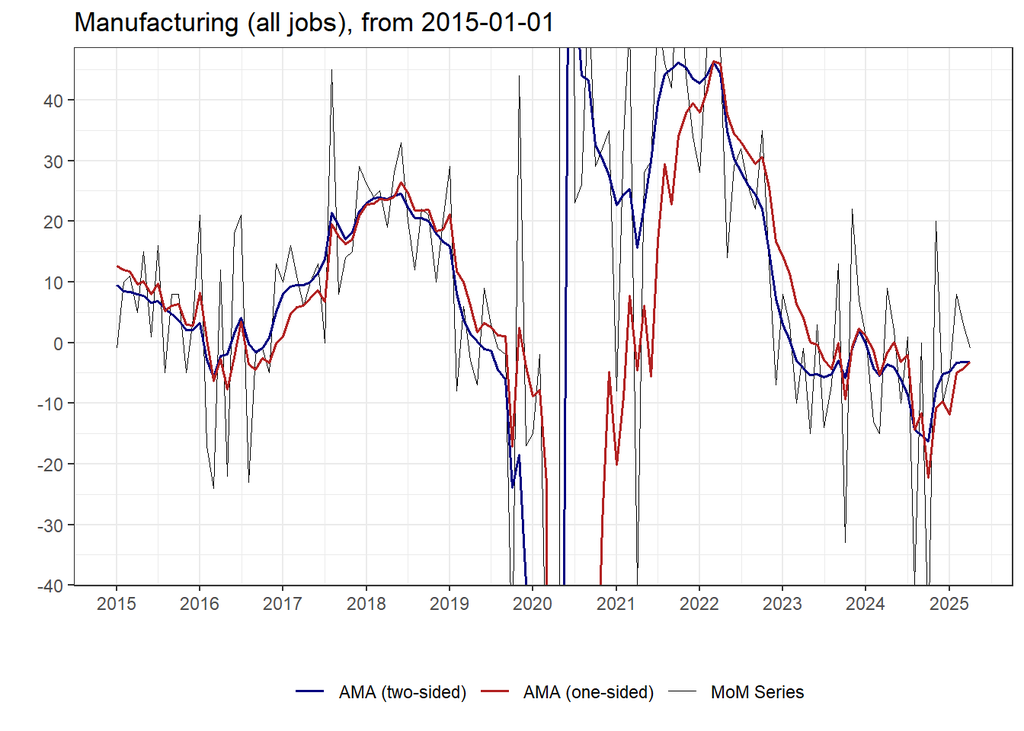

AMA Look-back Window (Right)

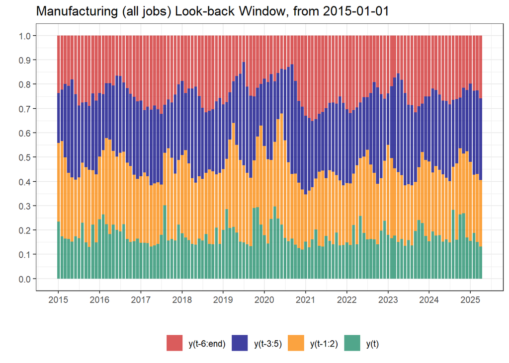

##### Durable goods

AMA Job Results

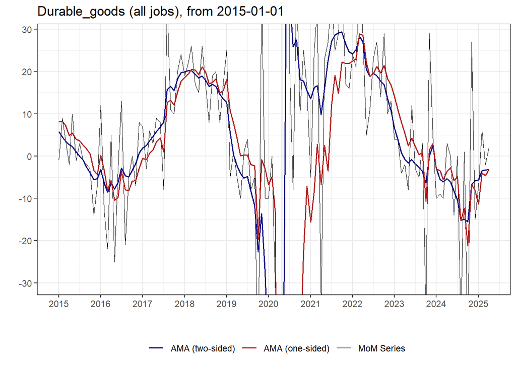

AMA Look-back Window (Right)

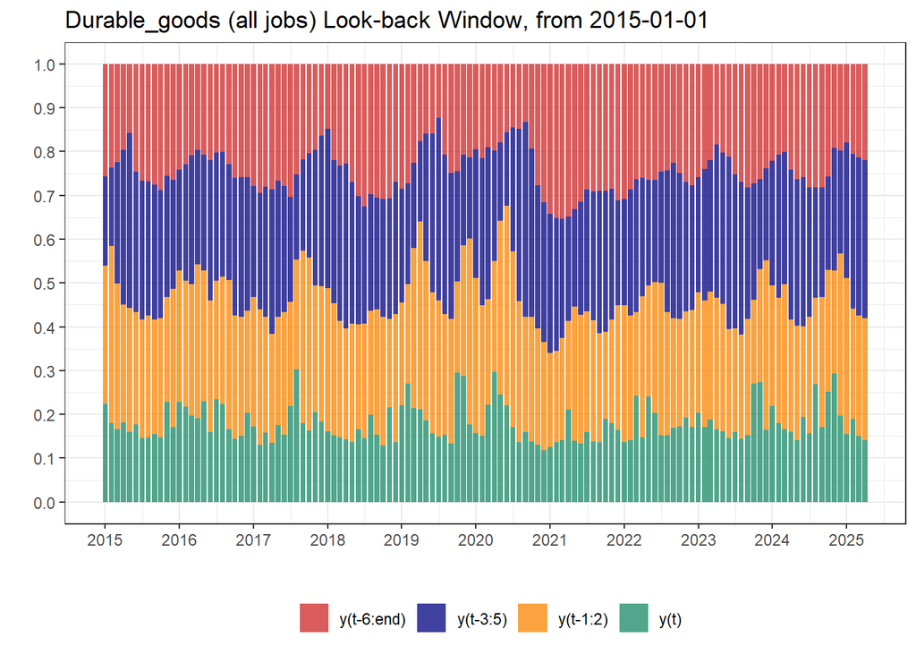

##### Nondurable goods

AMA Job Results

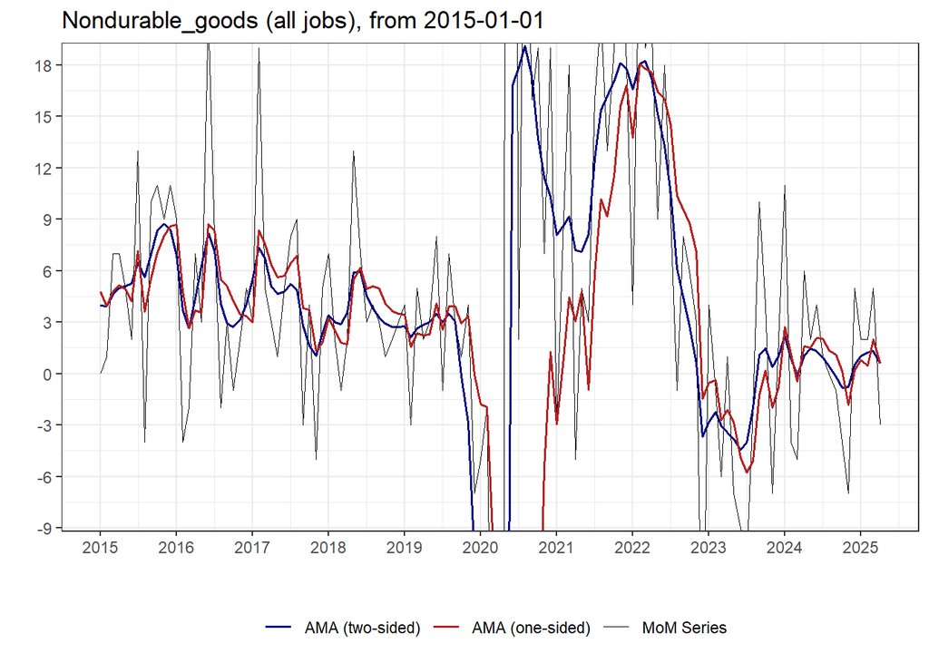

AMA Look-back Window (Right)

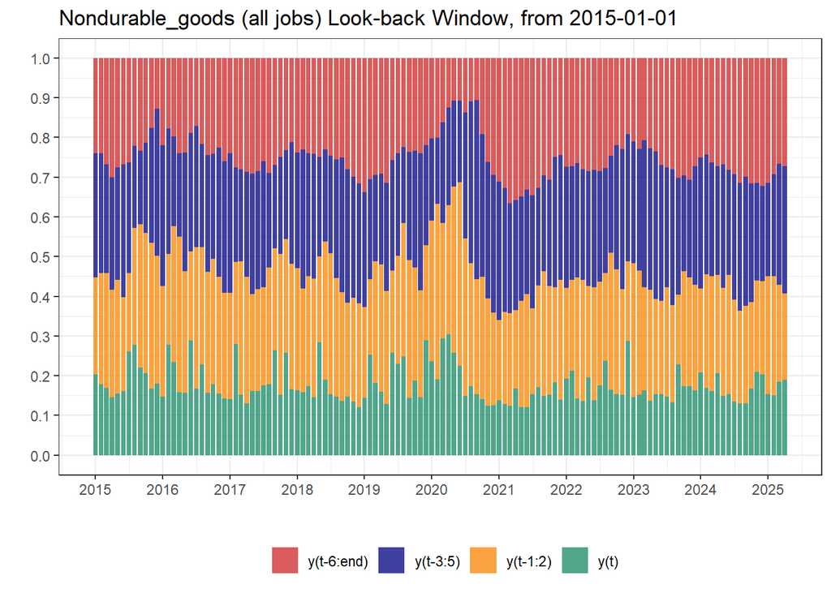

### Private service-providing

AMA Job Results

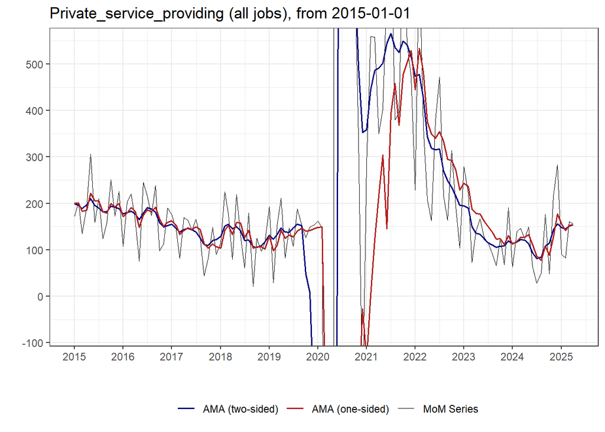

AMA Look-back Window (Right)

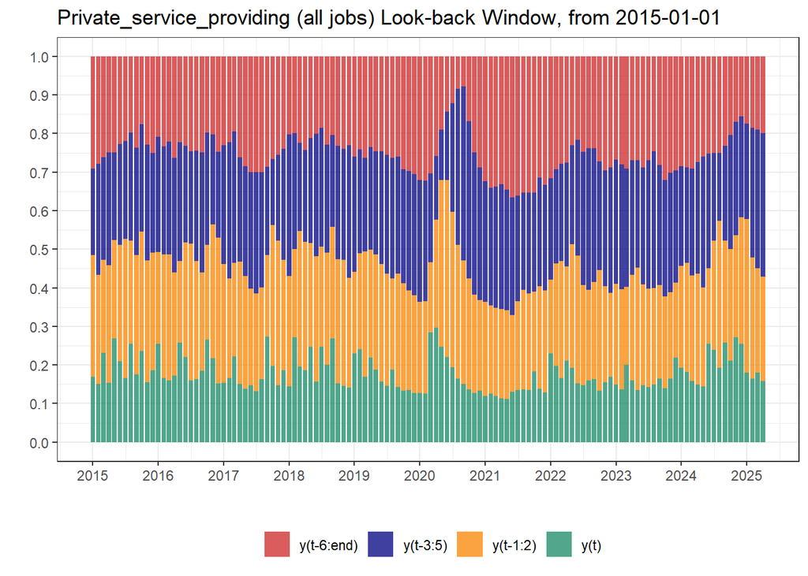

#### Trade, transportation, and utilities

AMA Job Results

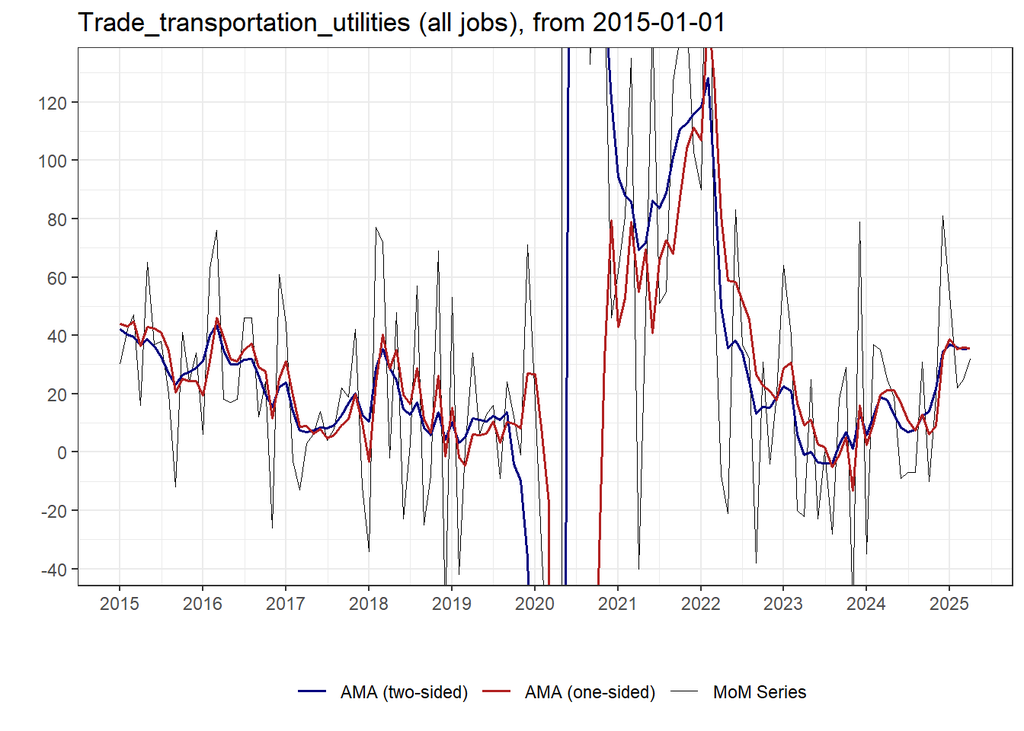

AMA Look-back Window (Right)

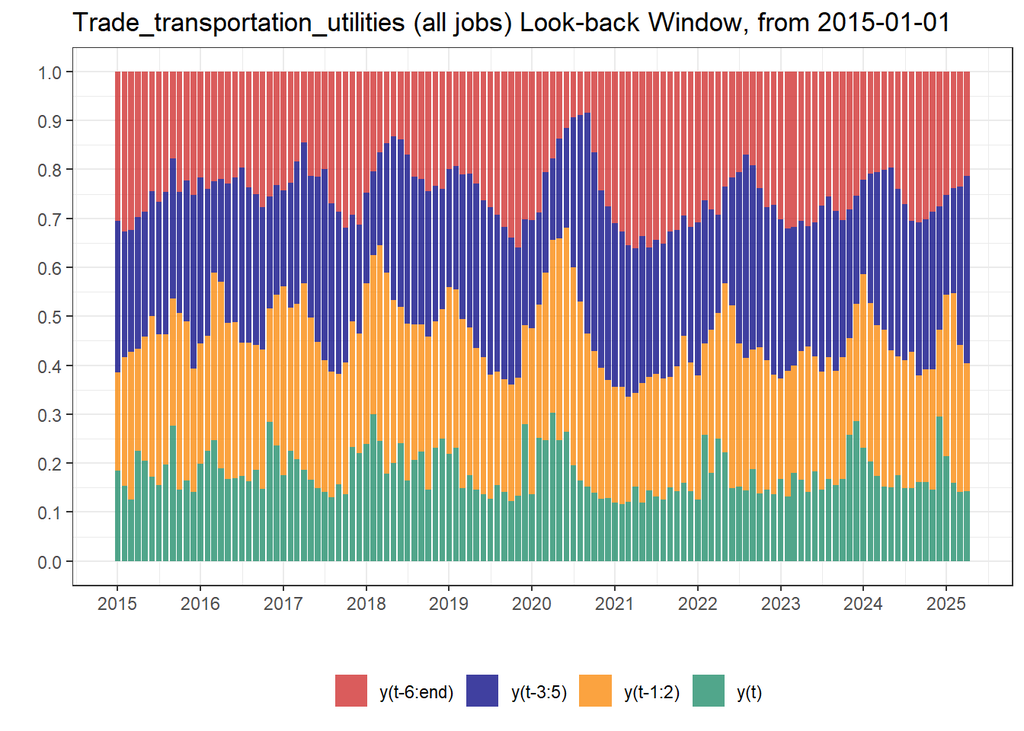

##### Wholesale trade

AMA Job Results

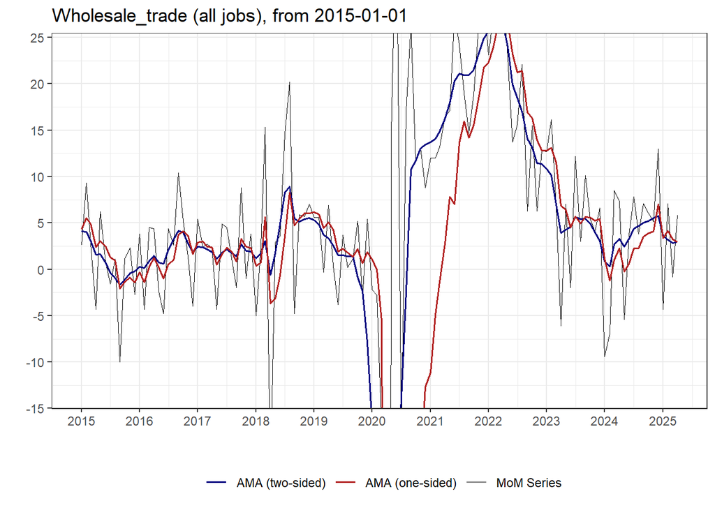

AMA Look-back Window (Right)

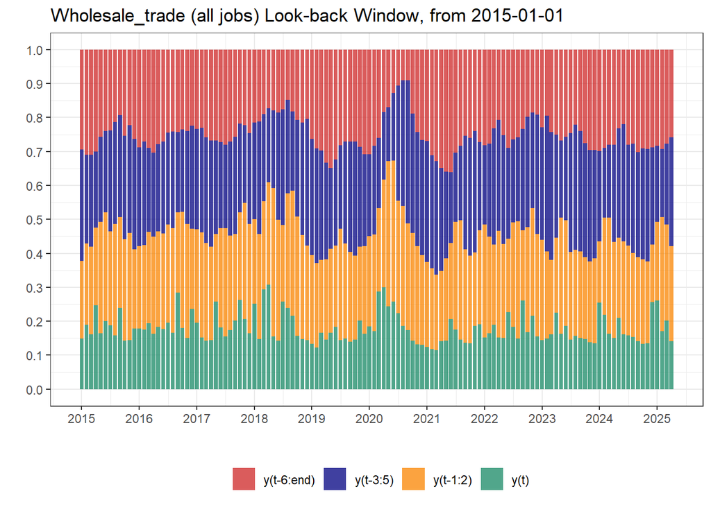

##### Retail trade

AMA Job Results

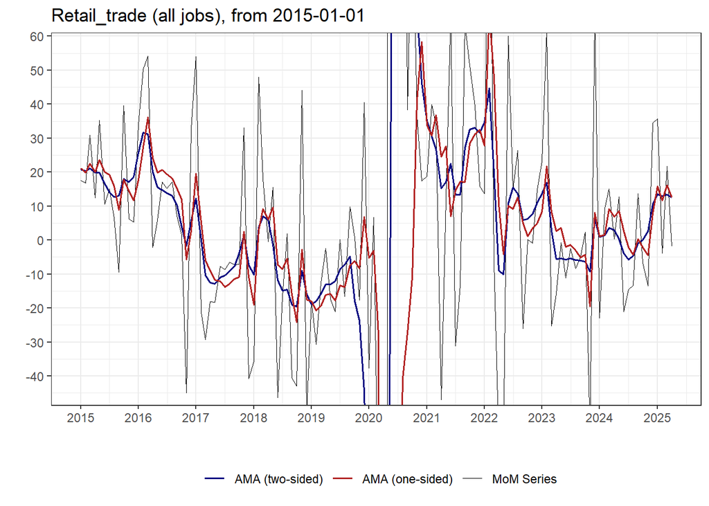

AMA Look-back Window (Right)

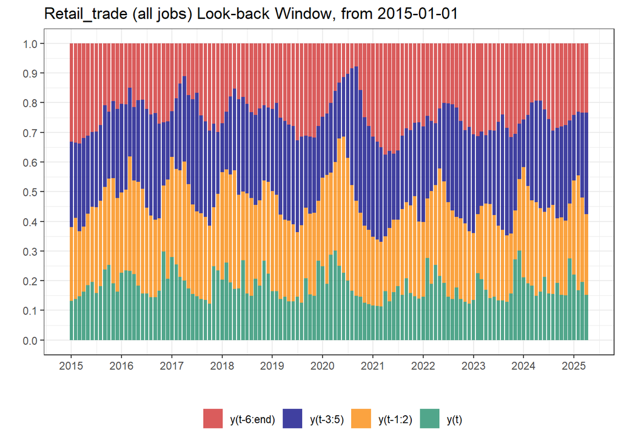

##### Transportation and warehousing

AMA Job Results

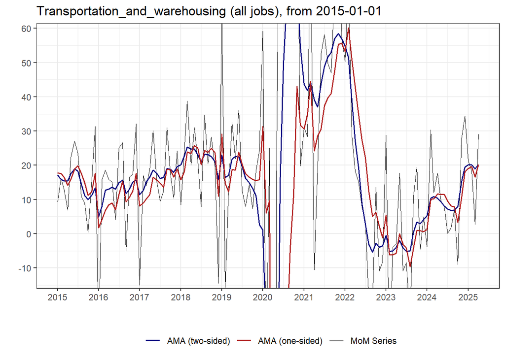

AMA Look-back Window (Right)

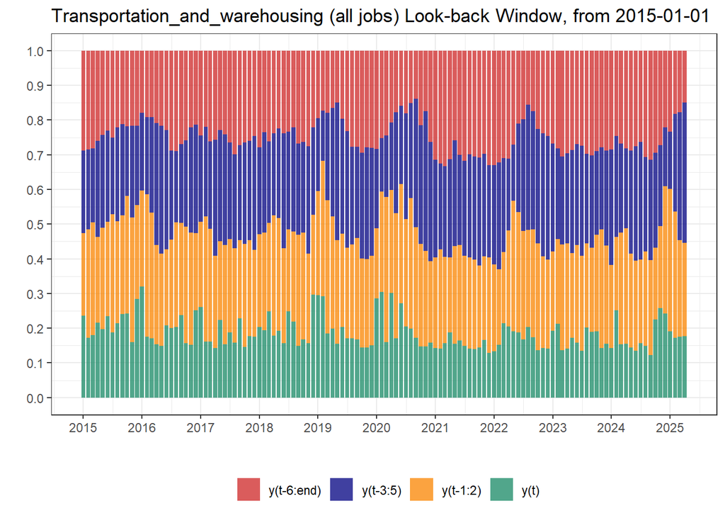

##### Utilities

AMA Job Results

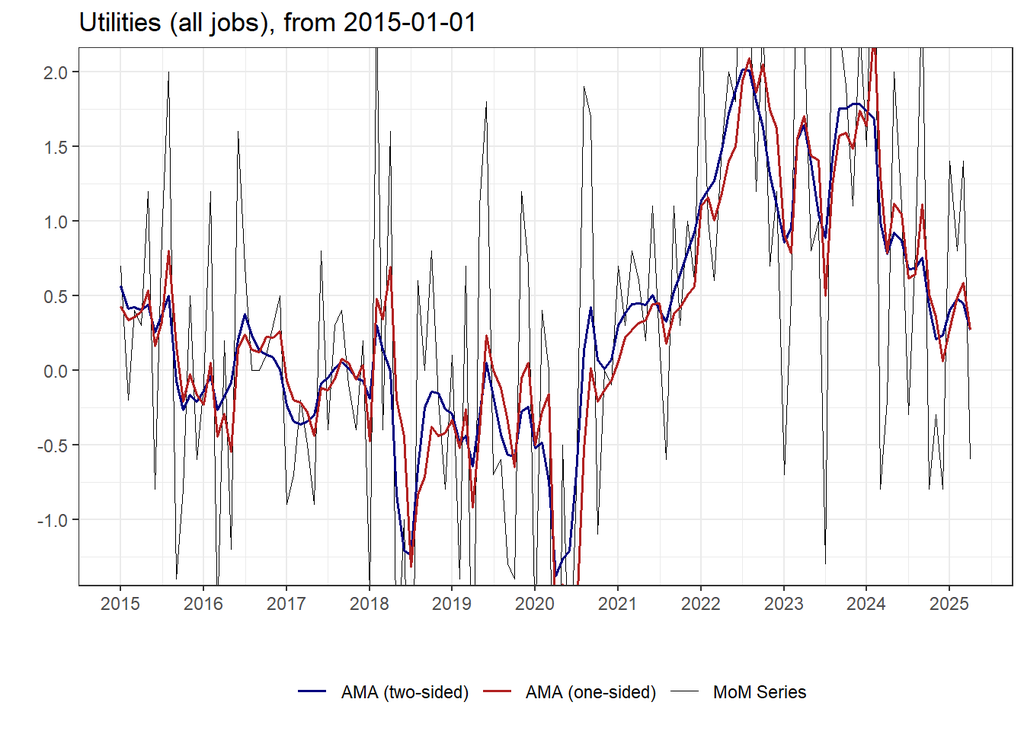

AMA Look-back Window (Right)

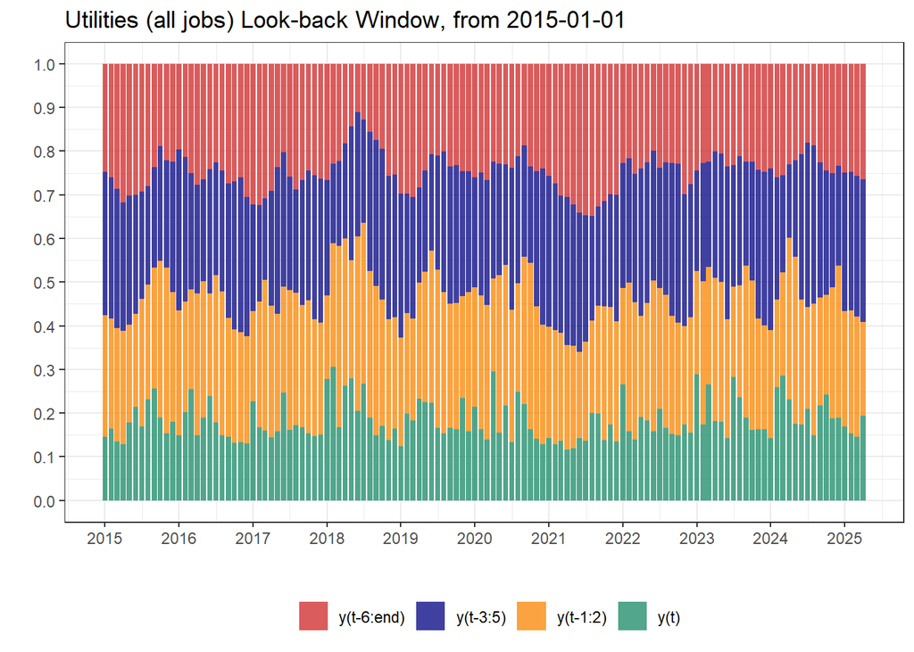

#### Information

AMA Job Results

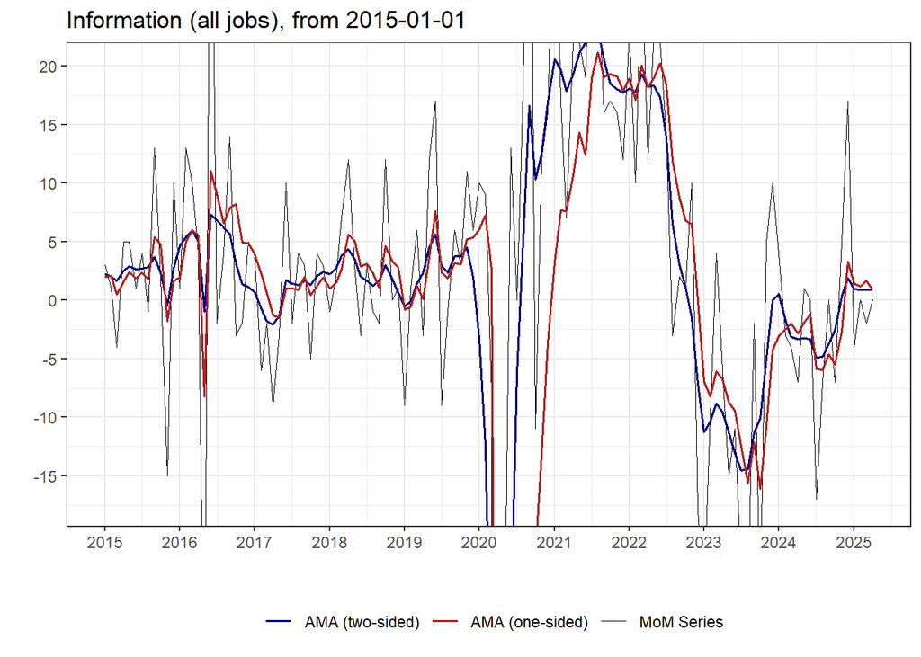

AMA Look-back Window (Right)

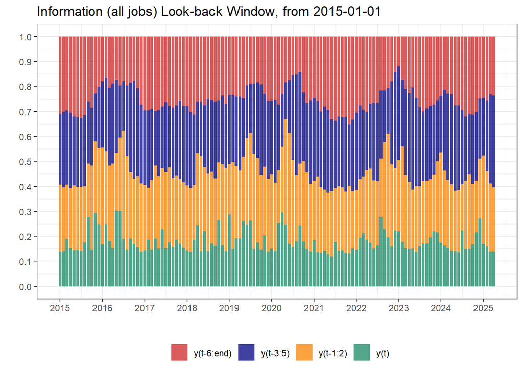

#### Financial activities

AMA Job Results

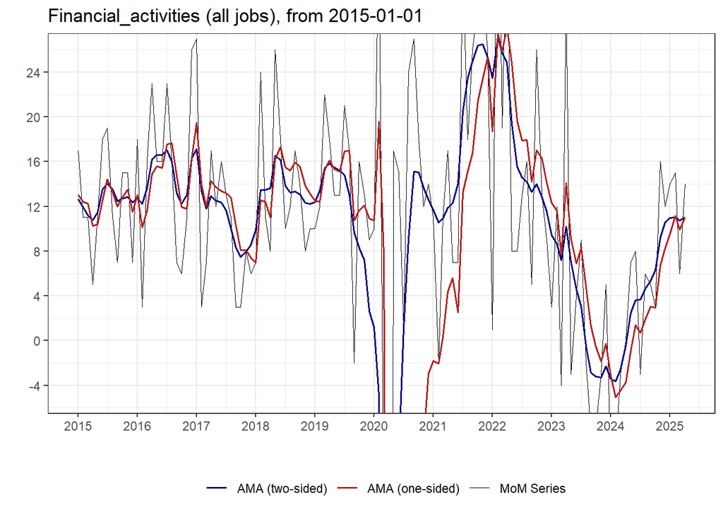

AMA Look-back Window (Right)

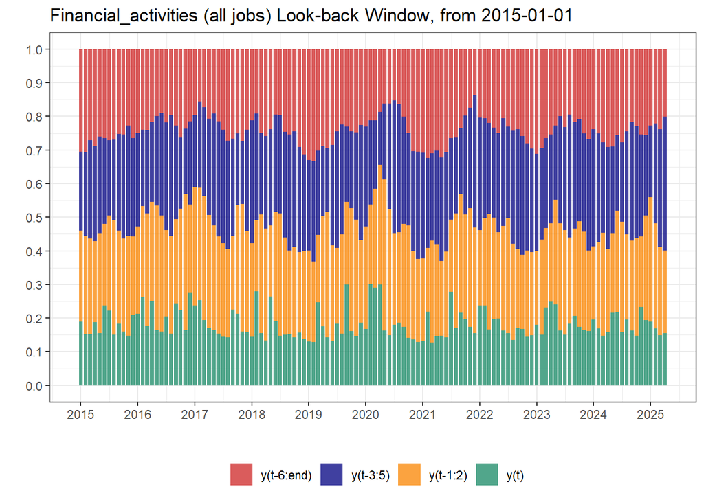

#### Professional and business services

AMA Job Results

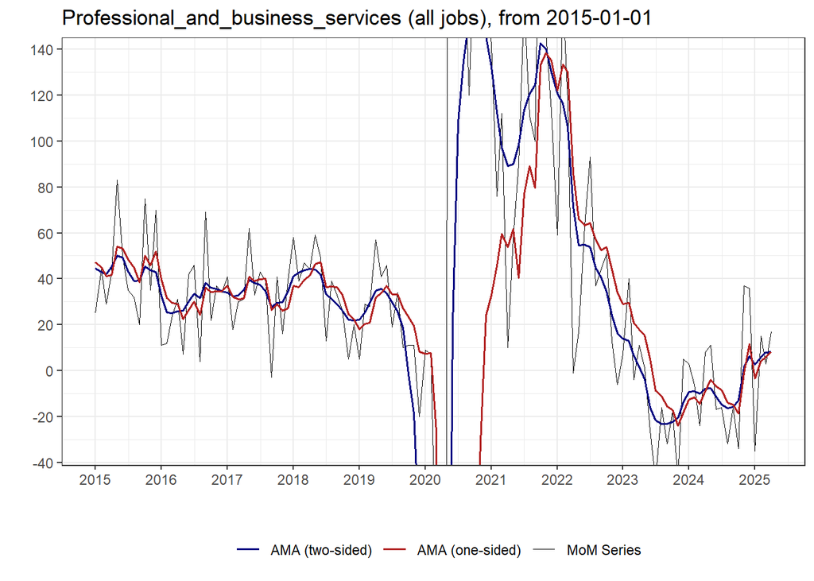

AMA Look-back Window (Right)

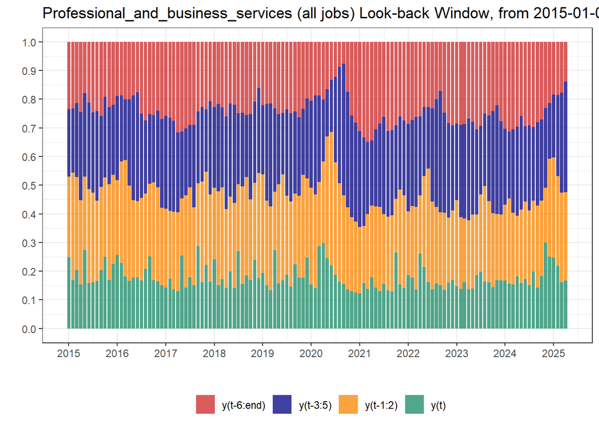

#### Education and health services

AMA Job Results

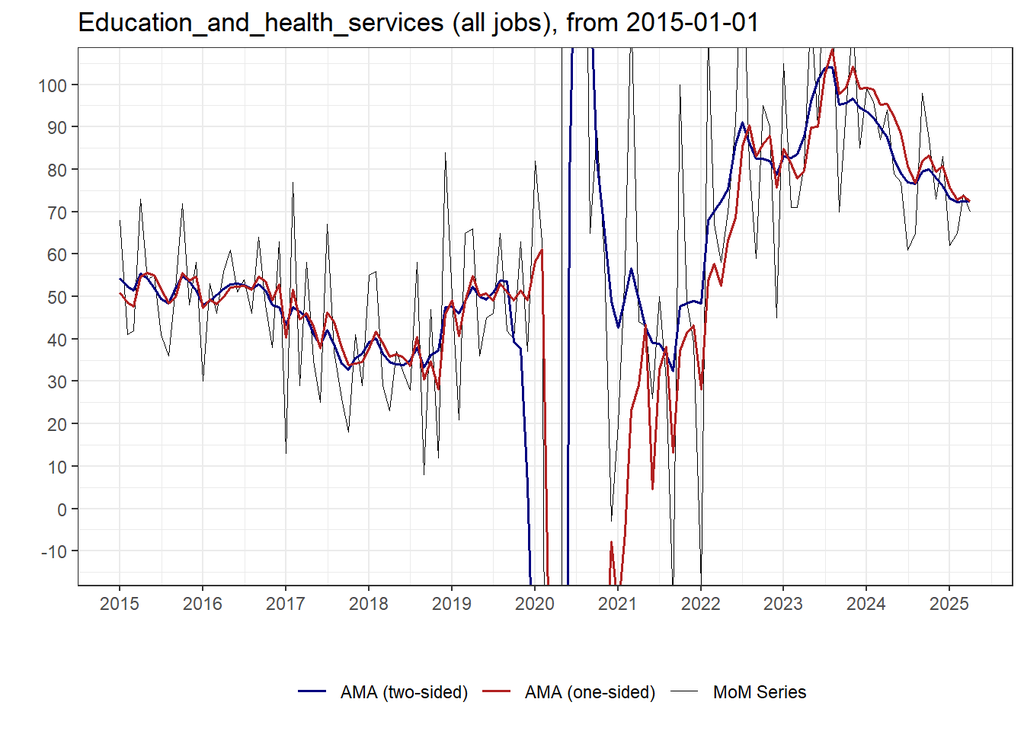

AMA Look-back Window (Right)

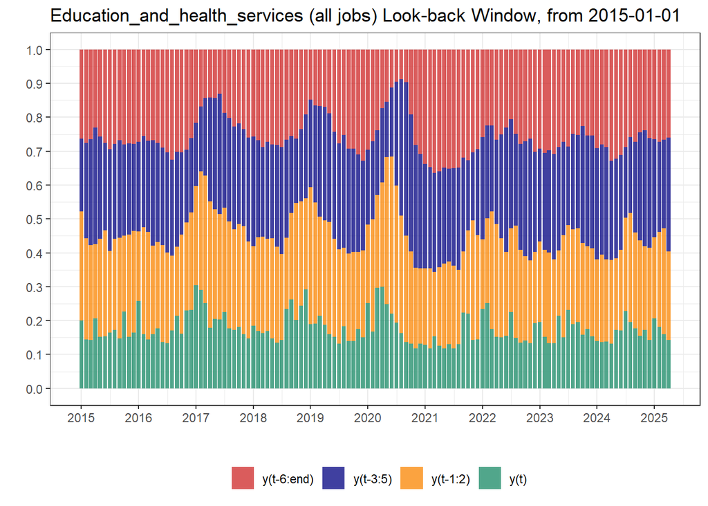

#### Leisure and hospitality

AMA Job Results

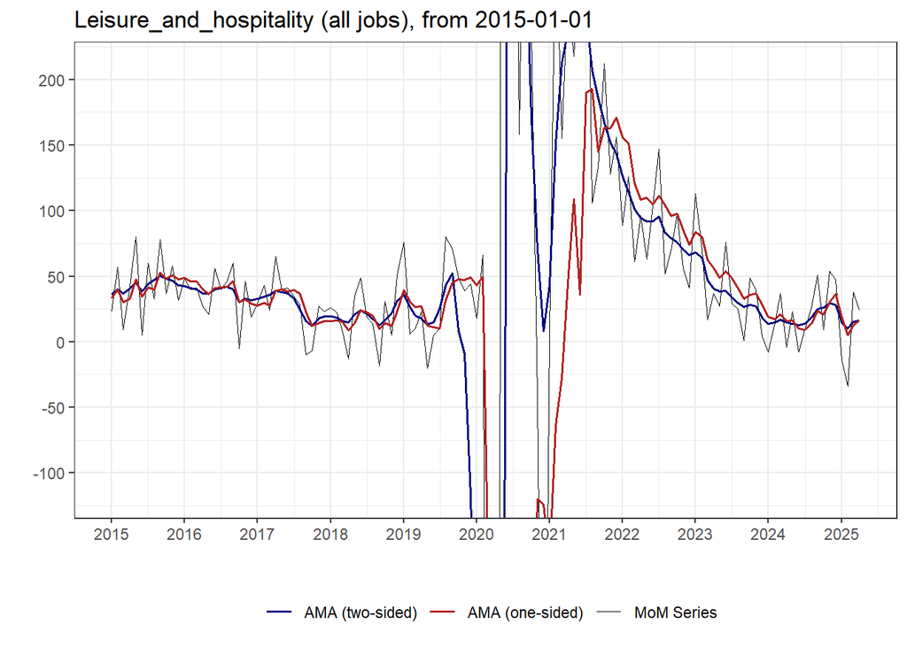

AMA Look-back Window (Right)

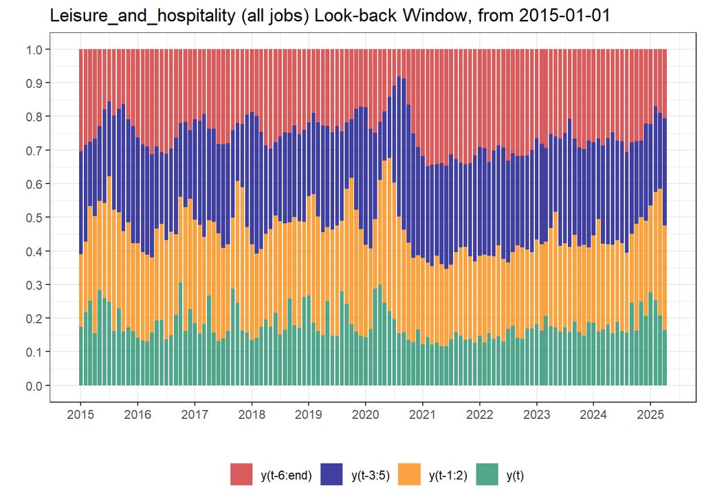

#### Other services

AMA Job Results

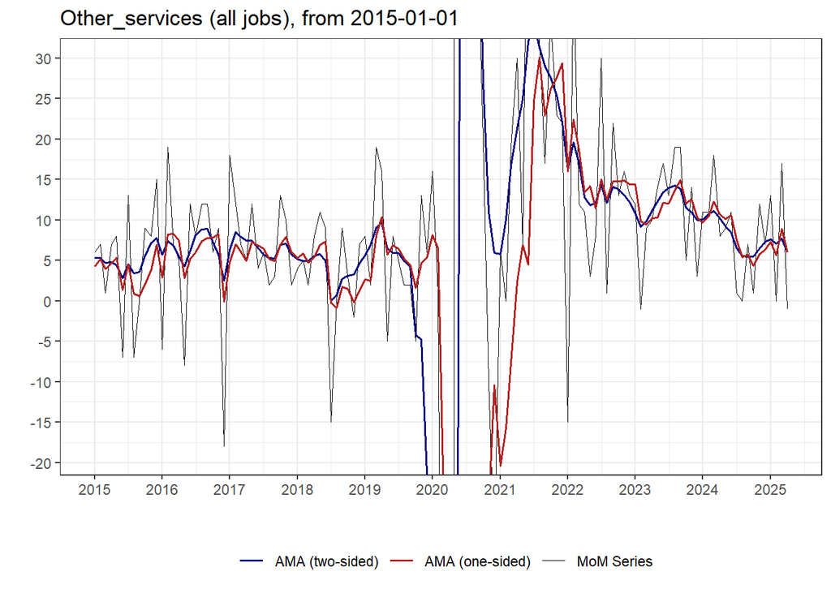

AMA Look-back Window (Right)

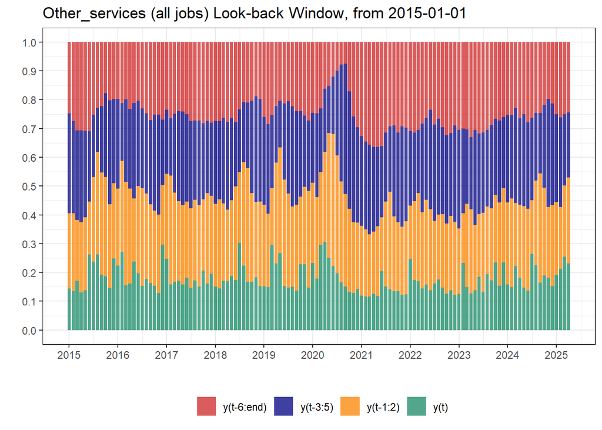

## Government

AMA Job Results

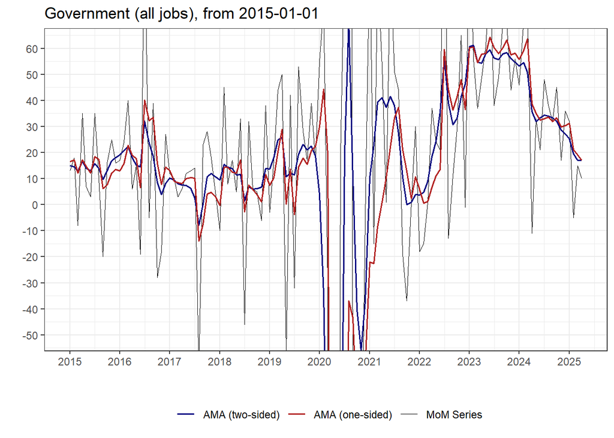

AMA Look-back Window (Right)

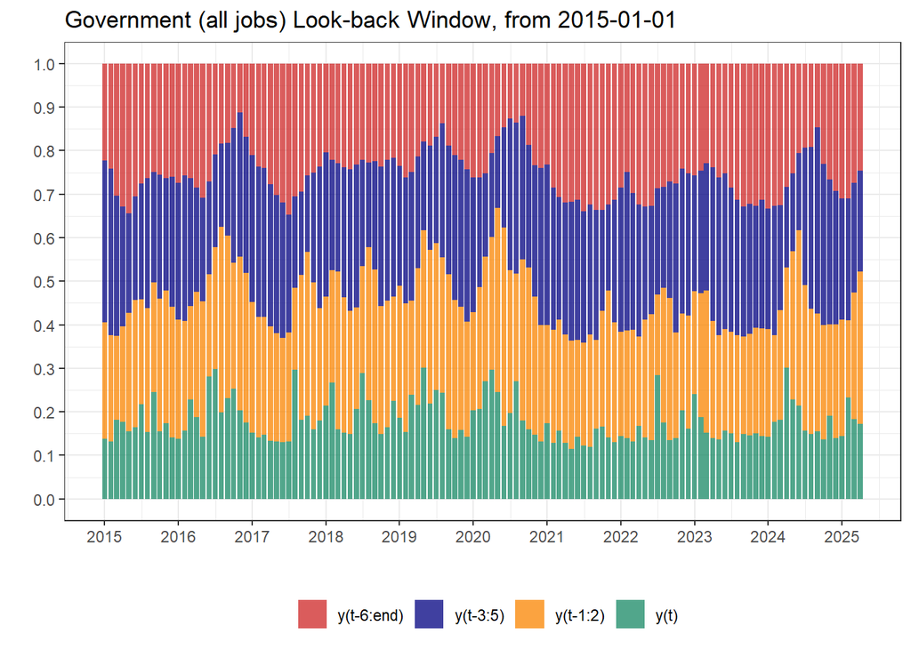

### Federal

AMA Job Results

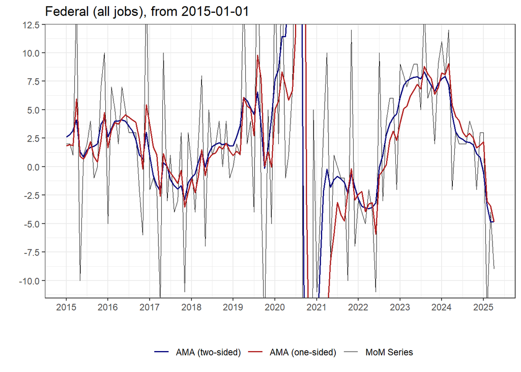

AMA Look-back Window (Right)

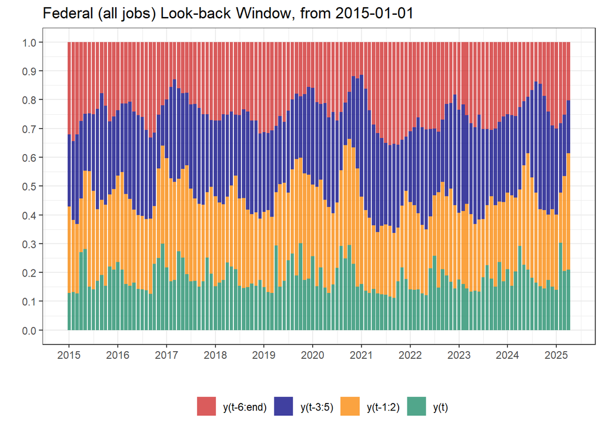

### State government

AMA Job Results

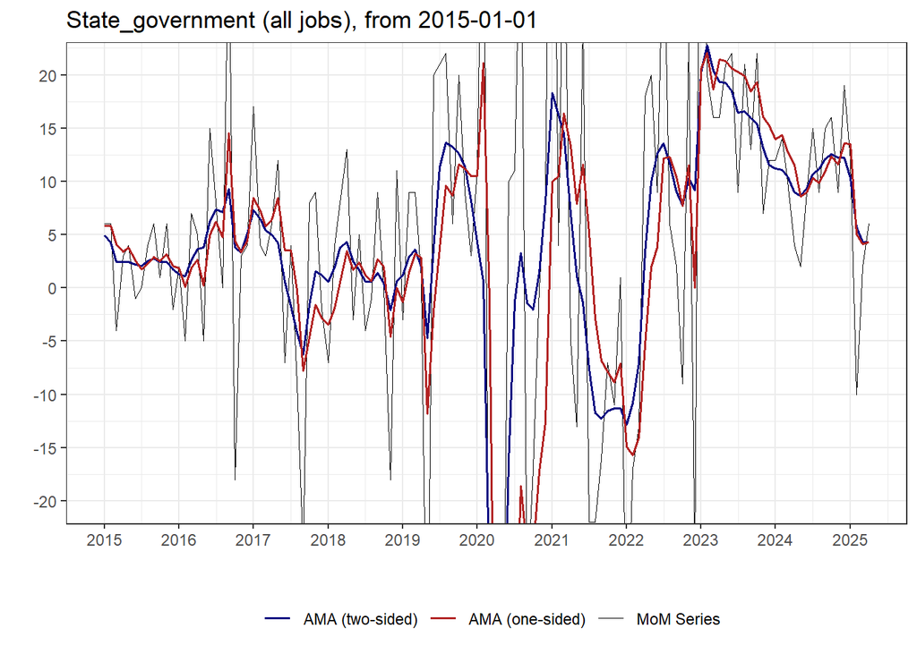

AMA Look-back Window (Right)

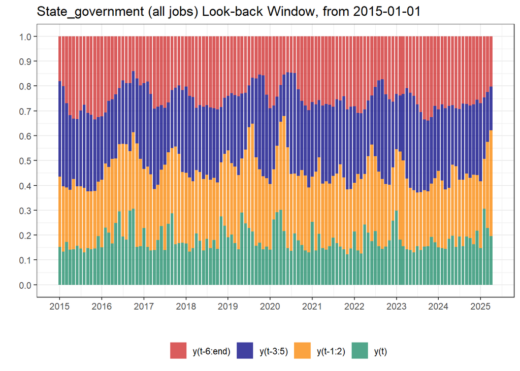

### Local government

AMA Job Results

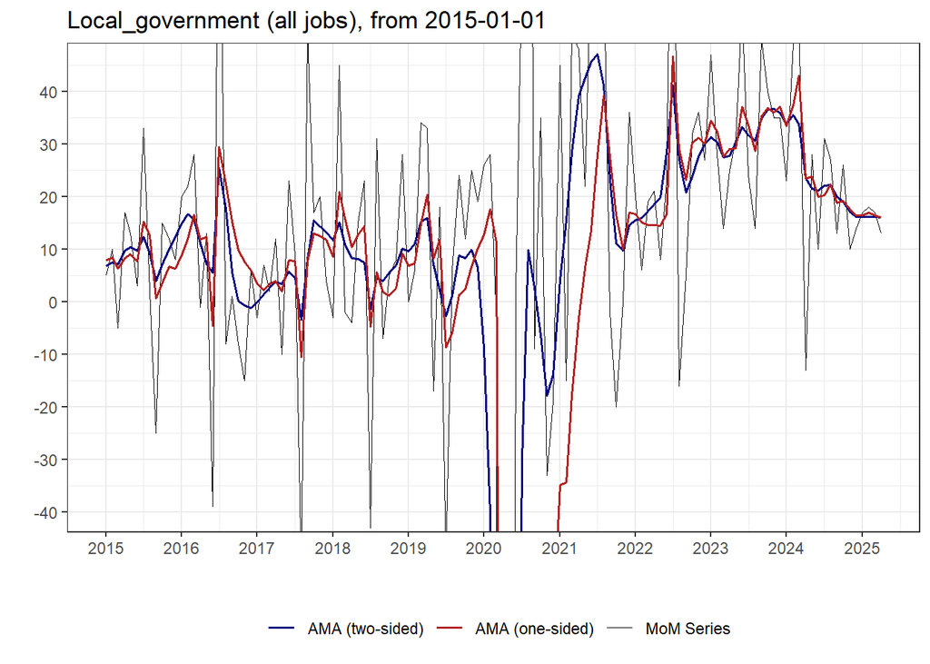

AMA Look-back Window (Right)

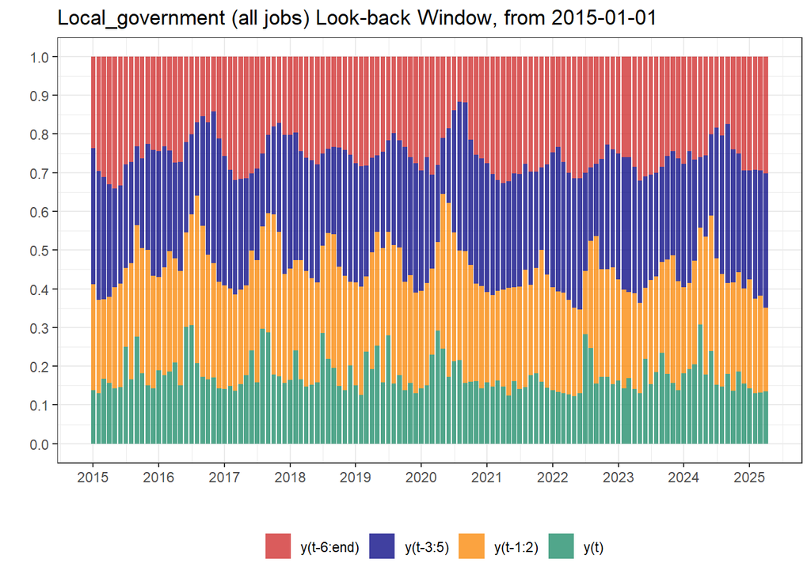